# IST 707 Bonus Project

Tejas Patil

2020 M05 3

#### **Executive Summary**:

##### **Problem Statement:**

##### The objective of this assignment is to analyze the given data and build machine learning models which are able to identify the ‘Pulsar stars’. Receivers are placed around different locations on Earth which receive the electro-magnetic signal and store the data. This data is processed and transformed to a correct form to use for future predictions. We are looking for electro-magnetic pulses of high intensity emitted by the Pulsar stars that sweep through the universe. Most of the signals are merely radio frequency interference (RFI) produced from the planet earth. This data is thus imbalanced, with very rare and important points reflecting ‘Pulsar stars.’

##### **1. Data Load and Cleanup:**

##### This section deals with cleaning the data. We’ll check the data for missing values, outliers etc. and treat those observations with suitable values. The data will also be checked for presence of any duplicate values. It also includes statistical analysis of the data.

##### **2. Exploratory Data Analysis: Part 1**

##### This section involves a deeper understanding of the data using tabular and visual representation of the data. The importance of features with respect to classification of target variable will be observed. Features will be tested for multi-collinearity and significance.

##### **3. Exploratory Data Analysis: Part 2**

##### In supervised learning, we are only interested in separating the pulsars from the rest. While unsupervised learning is more about organizing the data points in an unspecified number of natural categories. Hence, we will perform unsupervised learning (clustering) to identify the terrestrial/extra-terrestrial interference in the data.

##### **4.Model building and evaluation:**

##### Two supervised learning classification models will be built to predict the predict the pulsar stars. Models will be evaluated based on suitable evaluation parameters **(Accuracy and Recall)**

##### Link to the Dataset: [https://www.kaggle.com/pavanraj159/predicting-a-pulsar-star/download]

### **1. Data load and Cleanup**

##### Importing the necessary libraries

```r
library(ggplot2)
library(gridExtra)
library(corrplot)
library(tidyverse)
library(viridis)
library(caret)
library(DMwR)
library(factoextra)
library(pROC)
library(recipes)
library(keras)
library(yardstick)
```

##### Importing the csv file into R enviornment and checking the structure (data type of variables) of the dataset.

##### We observed that the target variable is binary and depending on the problem statement, converting the target variable to factor data type.

##### The dataset has 8 independent variables and 1 dependent variable. All the independent variables are calculated from a single signal.

```r
pulsar_df <- read.csv('pulsar_stars.csv', stringsAsFactors = T)
#str(pulsar_df)
pulsar_df$target_class <- as.factor(pulsar_df$target_class)
```

##### Renaming the variables to short names and checking the statistical summary of the dataset.

##### All the independent variables are of numeric data type and are of different scales.

```r
colnames(pulsar_df) <- c('Mean_Int_Prof', 'Std_Int_Prof', 'ExKurt_Int_Prof', 'Sk_Int_Prof', 'Mean_DMSNR', 'Std_DMSNR', 'ExKurt_DMSNR', 'Sk_DMSNR', 'Pulsar')
#summary(pulsar_df)
```

##### Checked the data for Missing values. The results returned shows us that there are **no missing values** in the data

```r
apply(is.na(pulsar_df),2,sum)
```

```
##   Mean_Int_Prof    Std_Int_Prof ExKurt_Int_Prof     Sk_Int_Prof      Mean_DMSNR
##               0               0               0               0               0
##       Std_DMSNR    ExKurt_DMSNR        Sk_DMSNR          Pulsar
##               0               0               0               0
```

##### Checked the data for duplicate observations. The results returned shows us that there are **no duplicate observations** in the data.

```r
nrow(pulsar_df) - nrow(unique(pulsar_df))
```

```
## [1] 0
```

### **2. Exploratory Data Analysis: Part 1**

#### **Analysing the target variable**

##### We find that the target variable is of binary type and has 2 levels in it. So, this is a binary classification problem.

##### __Imbalanced Data:__ The positie values in data are 1639, which is very less as compared to the negavtive results, 16259.

```r
str(pulsar_df$Pulsar)
```

```
##  Factor w/ 2 levels "0","1": 1 1 1 1 1 1 1 1 1 1 ...
```

```r
table(pulsar_df$Pulsar)
```

```
##
##     0     1
## 16259  1639
```

##### For analyzing the data, we create a new dataframe containing only numerical attributes (independent variables).

```r
num_df <- pulsar_df[sapply(pulsar_df, is.numeric)]
#str(num_df)
```

##### Creating a function to generate a grid plot for displaying boxplots for all the numerical variables. We see that there are considerable **outliers** in all the in this dataset variables.

##### It is observed that almost all the numerical variables in this data contain outliers. Although outliers should be treated, in this case outliers might be very important for predictions, as high intensity pulsar signals are very different from radio waves interference.

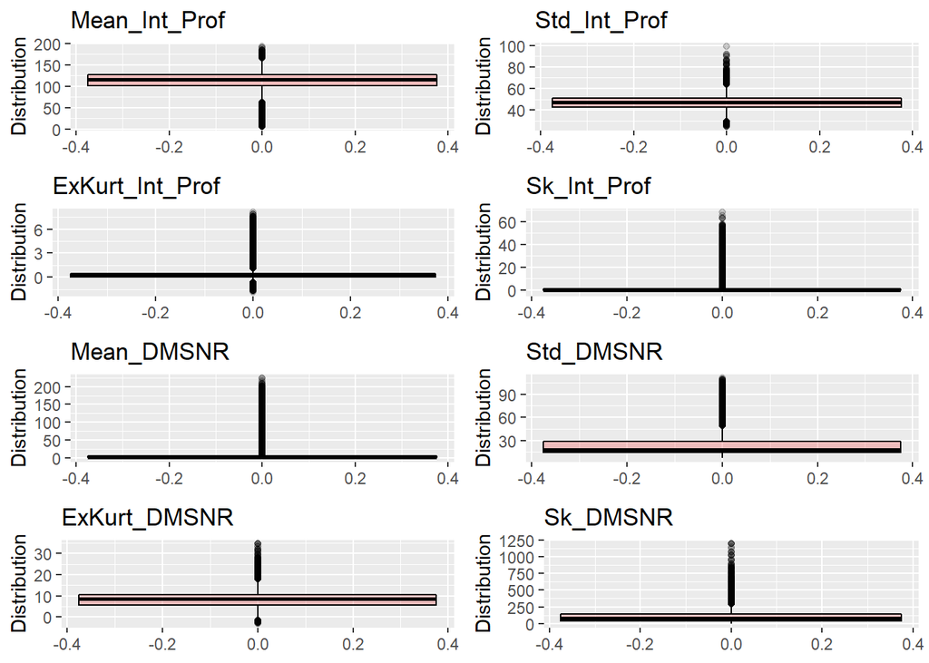

```r
box_plot <- function(data_in, i) {
  p <- ggplot(data_in, aes(y = data_in[,i])) + geom_boxplot(color="black", fill="red", alpha=0.2) + ggtitle(colnames(data_in)[i]) + ylab("Distribution") + theme(legend.position="none")
  return (p)
}

mygrid2 <- list()
for (i in 1:length(num_df)){
  myplot2 <- box_plot(num_df, i)
  mygrid2 <- c(mygrid2, list(myplot2))
}
do.call("grid.arrange", c(mygrid2, ncol=2))
```

##### Since, the outliers might be important in this case, we create **two datasets**. One treated with outliers and second without treating the outliers.

##### ‘no_outliers_df’ will be treated for outliers.

##### ‘pulsars_df’ will **NOT** be treated for outliers.

```r
no_outliers_df <- pulsar_df
```

##### Creating a function to treat outliers by winsorizing. We will use the **Inter-Quartile Range** method to winsorize the outliers.

```r
#Outlier Treatment by Winsorizing
Out_Treat_W = function(x){
  Q1 = quantile(x, 0.25)
  Q3 = quantile(x, 0.75)
  IQR = Q3 - Q1
  LC = Q1 - 1.5*IQR
  UC = Q3 + 1.5*IQR
  Out_Count = sum(x > UC | x < LC)
  UOut <- which(x > UC)
  LOut <- which(x < LC)
  for (i in 1:length(UOut)){
    x[UOut[i]] <- UC
  }
  for (i in 1:length(LOut)){
    x[LOut[i]] <- LC
  }
  return(x)
}

#Treating the outliers
for(i in 1:length(colnames(no_outliers_df))){
  if(class(no_outliers_df[,i]) == "numeric"){
    no_outliers_df[,i] <- Out_Treat_W(no_outliers_df[,i])
  }
}
```

##### Creating a function to generate Histogram for numerical variables. Implementing that function on every variable in num_df dataset.

##### Note: Here we will be checking the distribution of numerical variables that are not treated for outliers.

##### Observations: It is observed that Mean, standard deviation of Integrated profile and Kurtosis for DM-SNR curve are normally distributed. All other variables have a right-skewed distribution.

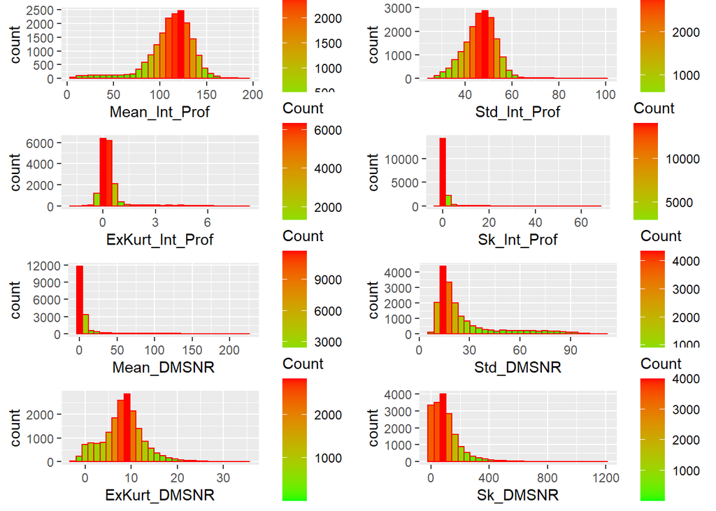

```r
hist_plot <- function(data_in, i) {
  data <- data.frame(x=data_in[[i]])
  p <- ggplot(data=data, aes(data[,1])) +
    geom_histogram(bins = 30, col="red", aes(fill=..count..)) +
    xlab(colnames(data_in)[i]) +
    scale_fill_gradient("Count", low="green", high="red")
  return (p)
}
mygrid2 <- list()
for (i in 1:length(num_df)){
  myplot2 <- hist_plot(num_df, i)
  mygrid2 <- c(mygrid2, list(myplot2))
}
do.call("grid.arrange", c(mygrid2, ncol=2))
```

##### **Correlation Plot:** Plotting the correlation matrix to check for the **multicollinearity** between numeric independent variables. We observe that Kurtosis and skewness for both Integrated profile and DM-SNR curve are **highly correlated** respectively. Multi-collinearity can be a problem if we are using the data for **regression** models as highly correlated variables will affect the value of coefficient of each other. Since, we do not plan to use regression algorithms for this assignment, we will not make any changes.

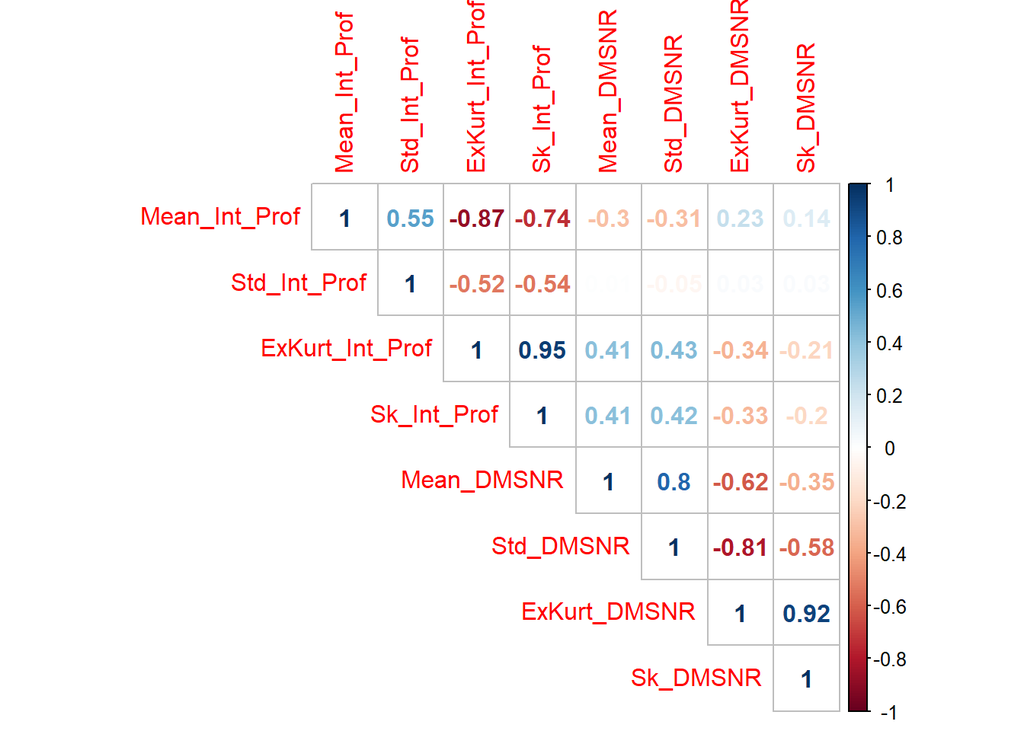

```r
corMatrix <- cor(num_df)
corrplot(corMatrix, method = "number", type = "upper")
```

#### **Bivariate Analysis:**

##### Making a function to plot boxplots for bivariate analysis

```r
bivariate_plot <- function(num_var, title){
  plt <- pulsar_df %>% ggplot( aes(x=Pulsar, y=num_var, fill=Pulsar)) + geom_boxplot() +
    scale_fill_viridis(discrete = T, alpha=0.5) +
    theme(legend.position="none", plot.title = element_text(size=11)) +
    ggtitle(title) + xlab("Pulsar Star") + ylab("Distribution")
  return(plt)
}
```

##### **Mean Integrated Profile Vs Pulsar**: Mean of Integrated profile for a particular signal is relatively lower for the signals of actual pulsar stars.

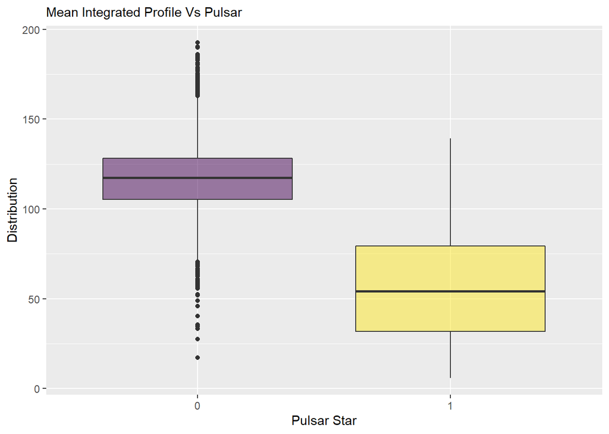

```r
bivariate_plot(pulsar_df$Mean_Int_Prof, "Mean Integrated Profile Vs Pulsar")
```

##### **Kurtosis Integrated Profile Vs Pulsar**: Kurtosis is the measurement of sharpness of the peak of a frequency distribution curve. It is observed that the peakedness of the curve of integrated profile distribution is higher for actual pulsar signals.

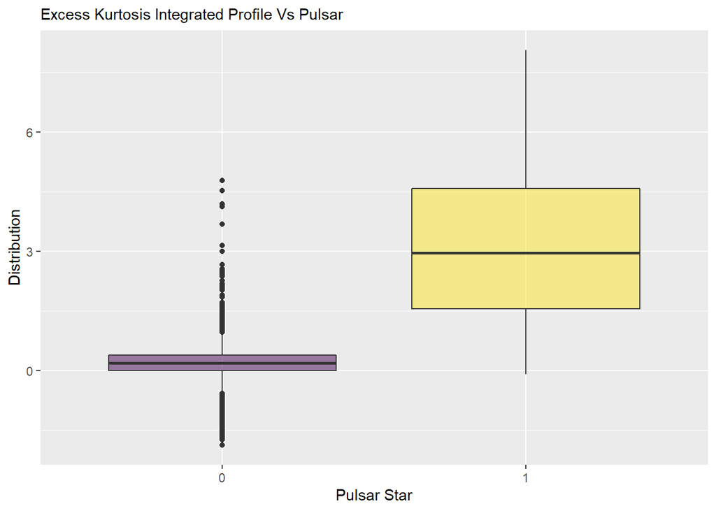

```r
bivariate_plot(pulsar_df$ExKurt_Int_Prof, "Excess Kurtosis Integrated Profile Vs Pulsar")
```

##### **Standard Deviation DM-SNR Curve Vs Pulsar**: The standard deviation for the frequency distribution curve for DM-SNR if more for a pulsar signal than a random noise.

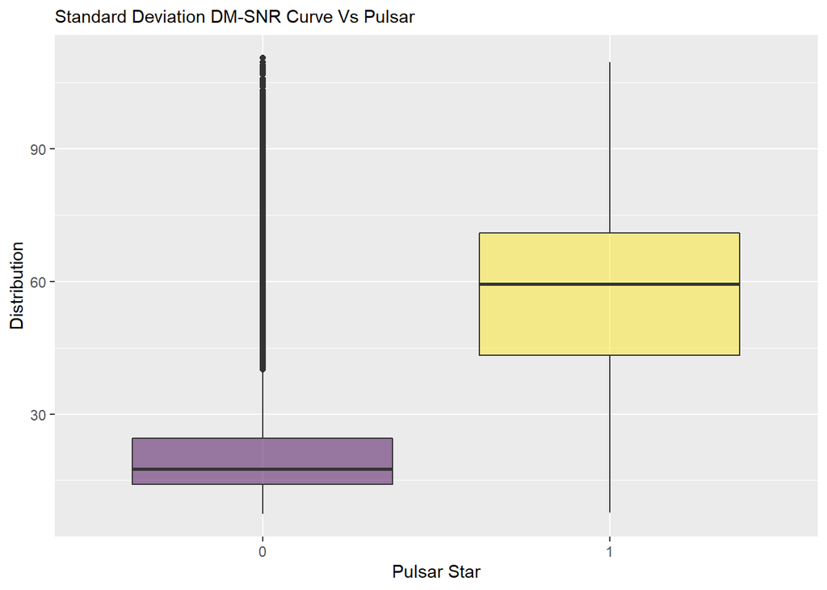

```r
bivariate_plot(pulsar_df$Std_DMSNR, "Standard Deviation DM-SNR Curve Vs Pulsar")
```

##### **Skweness DM-SNR Curve Vs Pulsar**: It is observed that the DM-SNR curve of an actual pulsar signal is less skewed than radio wave interference. Also, the distribution for pulsar signal is less spread out and is compact.

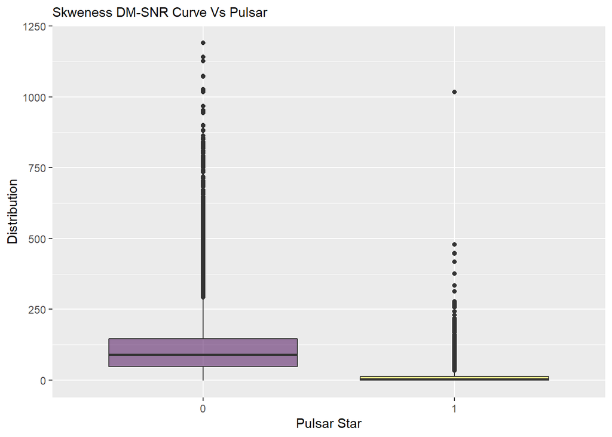

```r
bivariate_plot(pulsar_df$Sk_DMSNR, "Skweness DM-SNR Curve Vs Pulsar")
```

### **3. Exploratory Data Analysis: Part 2**

##### Unsupervised learning helps us identify the natural groups present in our data. In this case we want to identify the signal categories naturally present in our data. Most of the noise in the data is generated by the Radio frequency interference. Identifying the categories will help in identifying the sources of the signals, which will help in future to develop counter measures against them. But, all this is part of future scope of this project. We will use k-means clustering as a model for unsupervised learning.

#### **K-Means Clustering:**

##### K-means is a partitional type of clustering algorithm. It means that we must define the number of clusters prior to running the model. K-means is a **distance based** algorithm. Hence, we need to be careful about two things here.

##### 1] We’ll use the data that is treated for outliers. **Outliers** can affect the positioning of centroids of the clusters.

##### 2] We need to **normalize** or scale the data before performing clusterig analysis on the data.

```r
no_outliers_sc <- no_outliers_df[,-which(colnames(no_outliers_df) == "Pulsar")]

#Normalizing no_outliers_df
norm_ZN <- function(x){
  y <- c()
  for (i in 1:length(x)){
    y <- c(y, ((x[i]) - min(x))/(max(x) - min(x)))
  }
  return(y)
}
for(i in 1:length(colnames(no_outliers_sc))){
  no_outliers_sc[,i] <- norm_ZN(no_outliers_sc[,i])
}
```

##### To know the optimum number of clusters beforehand, the **elbow curve** needs to be plotted with sum of squared error on the Y-axis and number of clusters on X-axis. The sum of squared errors is calculated by taking the sum of the euclidean distance between centroid and each data point in that cluster. This process is repeated for each cluster. A sharp bend in the curve signifies a drastic decrease in reduction of sum of squared error. That point is considered as the optimum number of clusters.

##### For our data, the optimum number for clusters is 2. We specify maximum iterations for our model to be 100 which should be sufficient for the centroid points to attain their best position.

##### From the elbow curve, we know that there are **2** types of groups that naturally exist in our datasets.

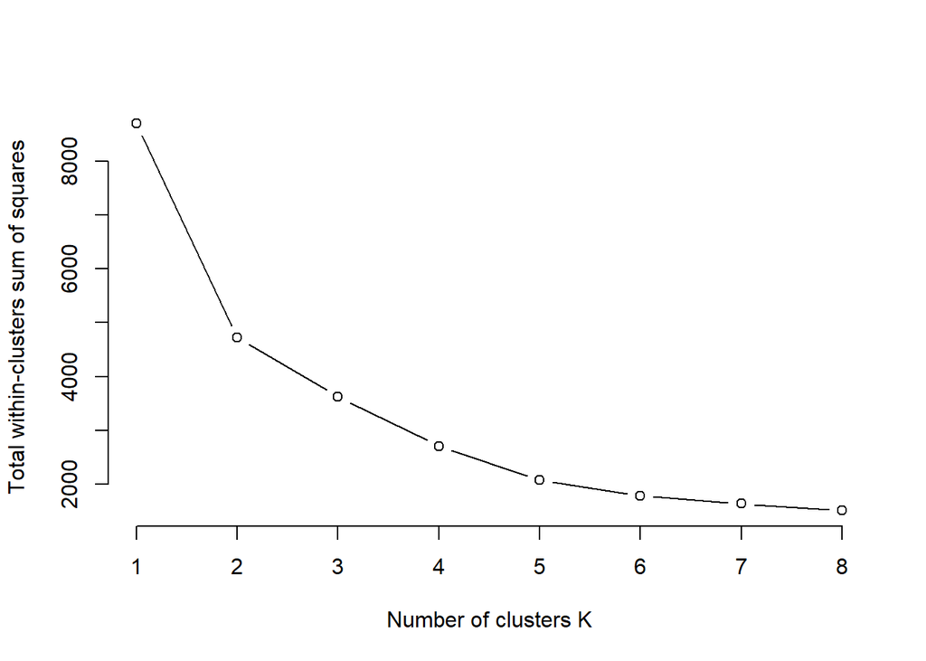

```r
set.seed(15)
find_K <- function(K){
  return(kmeans(no_outliers_sc, K, nstart = 20)$tot.withinss)
}
k_val <- 1:8
find_K_val <- purrr::map_dbl(k_val, find_K)
#Elbow Curve
plot(x = k_val, y = find_K_val,
     type = "b", frame = F,
     xlab = "Number of clusters K",
     ylab = "Total within-clusters sum of squares")
```

##### Building the final model of k-means clustering with K (no. of clusters = 2).

```r
kmeans_star <- kmeans(no_outliers_sc, centers = 2, nstart = 20, iter.max = 100, algorithm = "Hartigan-Wong")
```

##### Clusters 2D representation. The following graph shows the 2D representation of data points grouped into 2 clusters. It is observed that dimension 1 explains more than 50% of the variance in our data, while dimension 2 explains more than 30% of the variance in the data.

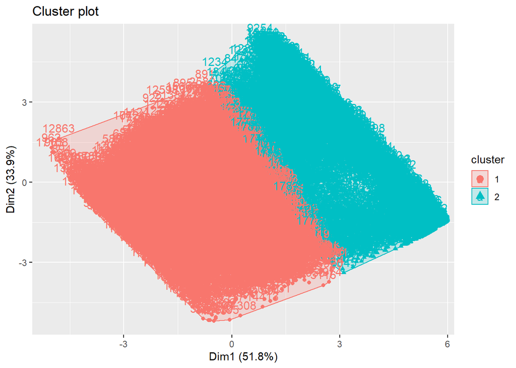

```r
fviz_cluster(kmeans_star, data = no_outliers_sc)
```

##### Standard Scaling the Data (Both ‘pulsar_df’ and ‘no_outliers_df’)

```r
for(i in 1:length(colnames(pulsar_df))){
  if(class(pulsar_df[,i]) == "numeric"){
    pulsar_df[,i] <- as.vector(scale(pulsar_df[,i]))
  }
}

for(i in 1:length(colnames(no_outliers_df))){
  if(class(no_outliers_df[,i]) == "numeric"){
    no_outliers_df[,i] <- as.vector(scale(no_outliers_df[,i]))
  }
}
```

##### Splitting the entire data into two parts, training and validating datasets. Here we are using **70-30** split.

##### Note: Splitting is performed on both **‘pulsar_df’** and **‘no_outliers_df’**.

```r
set.seed(73)
train_index <- createDataPartition(pulsar_df$Pulsar, p = 0.70, list = FALSE)
train_df <- pulsar_df[train_index, ]
validate_df <- pulsar_df[-train_index, ]

no_outliers_tr <- no_outliers_df[train_index, ]
no_outliers_val <- no_outliers_df[-train_index, ]
```

### **4. Model building and Evaluation**

##### For this assignment, we will be using 2 supervised machine learning models: Support Vector Machines and Artificial Neural Network.

##### a] **Support Vector Machines:** Since this is a classification problem and all the independent variables are numerical, distance based algorithms like Support vector machines and K-nearest neighbors will be a good fit over this data. Based on the performance of models in assignment 3, we choose SVM over KNN for this assignment.

##### b] **Artificial Neural Network:** Amongst all the classification algorithms studied in over the IST 707 course, Artificial neural network (with 2 hidden layers) and gradient boosting algorithm were the most efficient algorithm with respect to accuracy and time required, as seen in assignment 3. On this dataset, we tested both the models and it was seen that ANN2 gave better results than gradient boosting. Hence, we choose ANN2.

##### Note: The code for gradient boosting model is at the end of the assignement and is not a part of this assignment. It is just for reference.

### **a] Support Vector Machines: Non-Linear**

##### **Model Description:** Non-linear function helps in classification when a linear decision boundary is not able to classify the dataset. Mathematically, we should project the data into **higher dimensions** and use the same linear boundary (hyperplane) to seperate the classes. These **calculations become very complicated** especially for higher dimension. Hence, SVM uses **kernel trick** i.e. nothing but finding and applying a function that can perform the same calculations (measuring the similarity) in lower dimension only and hence reducing the computation time.

```r
svm_base_Out_Yes <- train(Pulsar ~ ., data = train_df, method = "svmRadial", verbose=F,
                          metric="Accuracy")
print(svm_base_Out_Yes)
```

```
## Support Vector Machines with Radial Basis Function Kernel
##
## 12530 samples
##     8 predictor
##     2 classes: '0', '1'
##
## No pre-processing
## Resampling: Bootstrapped (25 reps)
## Summary of sample sizes: 12530, 12530, 12530, 12530, 12530, 12530, ...
## Resampling results across tuning parameters:
##
##   C     Accuracy   Kappa
##   0.25  0.9789351  0.8656291
##   0.50  0.9791434  0.8678320
##   1.00  0.9793171  0.8696019
##
## Tuning parameter 'sigma' was held constant at a value of 0.474431
## Accuracy was used to select the optimal model using the largest value.
## The final values used for the model were sigma = 0.474431 and C = 1.
```

```r
#svm_base_Out_No <- train(Pulsar ~ ., data = no_outliers_tr, method = "svmRadial", verbose=F,
#                          metric="Accuracy")
#print(svm_base_Out_No)
```

```r
svm_base_predict <- predict(svm_base_Out_Yes, newdata = validate_df)
confusionMatrix(svm_base_predict, validate_df$Pulsar, positive = "1", mode = "prec_recall")
```

```
## Confusion Matrix and Statistics
##
##           Reference
## Prediction    0    1
##          0 4851   95
##          1   26  396
##
##                Accuracy : 0.9775
##                  95% CI : (0.9731, 0.9813)
##     No Information Rate : 0.9085
##     P-Value [Acc > NIR] : < 2.2e-16
##
##                   Kappa : 0.8552
##
##  Mcnemar's Test P-Value : 6.337e-10
##
##               Precision : 0.93839
##                  Recall : 0.80652
##                      F1 : 0.86747
##              Prevalence : 0.09147
##          Detection Rate : 0.07377
##    Detection Prevalence : 0.07861
##       Balanced Accuracy : 0.90059
##
##        'Positive' Class : 1
##
```

```r
#svm_base_predict_No <- predict(svm_base_Out_No, newdata = no_outliers_val)
#confusionMatrix(svm_base_predict_No, no_outliers_val$Pulsar, positive = "1", mode =
#                  "prec_recall")
```

### **Handling the imbalance problem:**

##### Since the data is imbalanced, accuracy won’t be a good measure to evaluate the performance of our model. We need to use the metric those are not sensitive to the imbalanced problem of target variable.

##### 1] **Recall:** Note that recall is very important is this problem because of two reasons. First, this data has already been surveyed and most of the pulsar stars have already been found. So, the new discoveries will be limited. So, our model needs to be as sensitive as possible such that False negative values should tend to 0. Second, the positive values in target variable are only those which previously have been identified as Pulsar. The aim of building this model is to find new observations those are pulsars. Hence, the recall values need to be as high as possible.

##### 2] **False Positive Rate:** The reason to check this parameter is that if our model identifies a **new pulsar star** (the one which was not discovered before), then that newly predicted pulsar star will fall into the category “false positive” with respect to old beliefs.

#### **SMOTE (Synthetic minority oversampling technique):**

##### It is very important to perform SMOTE sampling only on training data after the train test split. Otherwise, it might create a problem of data leakage from training to validation data.

##### New values counts are calculated as follows:

##### New Minority count = Original Minority count + [(perc.over / 100) x Original Minority count]

##### New Majority Count = [New Minority Count x (perc.under/100)] - [(perc.under/100) x Old Minority Count]

```r
set.seed(73)
train_sm <- SMOTE(Pulsar~., train_df, perc.over = 500, k = 30, perc.under = 200)
```

##### Checking the distribution of target variable after SMOTE. We tried to keep the count majority class same as before to prevent data loss. The minority class is oversampled to 6 times that of the original values.

```r
print("Previous distribution: ")
```

```
## [1] "Previous distribution: "
```

```r
print(table(train_df$Pulsar))
```

```
##
##     0     1
## 11382  1148
```

```r
print("After SMOTE distribution: ")
```

```
## [1] "After SMOTE distribution: "
```

```r
print(table(train_sm$Pulsar))
```

```
##
##     0     1
## 11480  6888
```

### **SVM NonLinear Tuned**

##### Non Linear SVM uses “svmRadial” function instead linear function for the calculation of the **similarity between landmarks and any given point**. For SVM, every other point is the landmark with respected to the given point. The similarity (distance) with every other observation is calculated for every observation. For this calculation svmRadial function is used.

##### **Hyperparameters:**

##### 1] **Cost Parameter ‘C’:** SVM can have **soft margin** which means it can have flexible decision boundary. It can be done by adding **slack variable** to the minimize function while creating the boundary. To **compensate for the slack variable** we have to add this **‘C’** parameter to the cost function. ‘C’ allows the misclassification of some points so we might get boundary with large margin and help in reducing the generalization error. Higher ‘C’ value might result in **overfitting**.

##### 2] **Sigma:** Sigma is a parameter of radial function. Radial function is similar to **Guassian distribution** where:

##### **lambda = 1/(2(sigma-squared))** where lambda is a gaussian parameter

```r
svm_nl_tuned <- train(make.names(Pulsar) ~ ., data = train_sm,
                      tuneGrid = expand.grid(sigma = seq(0.3, 0.5, 0.1), C = seq(1.5, 2.5,0.5)),
                      method = "svmRadial",
                      trControl = trainControl(method = "cv", number = 3, classProbs = T,
                                               summaryFunction = prSummary),
                      verbose=F, metric="Recall")

print(svm_nl_tuned)
```

```
## Support Vector Machines with Radial Basis Function Kernel
##
## 18368 samples
##     8 predictor
##     2 classes: 'X0', 'X1'
##
## No pre-processing
## Resampling: Cross-Validated (3 fold)
## Summary of sample sizes: 12245, 12245, 12246
## Resampling results across tuning parameters:
##
##   sigma  C    AUC        Precision  Recall     F
##   0.3    1.5  0.9814342  0.9518139  0.9859752  0.9685914
##   0.3    2.0  0.9816829  0.9523826  0.9861494  0.9689702
##   0.3    2.5  0.9821465  0.9527398  0.9869335  0.9695338
##   0.4    1.5  0.9806441  0.9521630  0.9865849  0.9690663
##   0.4    2.0  0.9812816  0.9525960  0.9872819  0.9696270
##   0.4    2.5  0.9818693  0.9528474  0.9875432  0.9698828
##   0.5    1.5  0.9806064  0.9524960  0.9868463  0.9693649
##   0.5    2.0  0.9817356  0.9530038  0.9874560  0.9699214
##   0.5    2.5  0.9824994  0.9528279  0.9871076  0.9696620
##
## Recall was used to select the optimal model using the largest value.
## The final values used for the model were sigma = 0.4 and C = 2.5.
```

##### **Very Important Observation:** Although, it is observed that precision is reduced to a smaller value, it means that new observations are classified as Pulsar stars **(False Positives)**. We need to focus on these data points as they might represent the pulsar star which are not discovered yet.

```r
svm_nl_tuned_predict <- predict(svm_nl_tuned, newdata = validate_df)
confusionMatrix(svm_nl_tuned_predict, as.factor(make.names(validate_df$Pulsar)), positive = "X1", mode = "prec_recall")
```

```
## Confusion Matrix and Statistics
##
##           Reference
## Prediction   X0   X1
##         X0 4803   61
##         X1   74  430
##
##                Accuracy : 0.9749
##                  95% CI : (0.9703, 0.9789)
##     No Information Rate : 0.9085
##     P-Value [Acc > NIR] : <2e-16
##
##                   Kappa : 0.8505
##
##  Mcnemar's Test P-Value : 0.3017
##
##               Precision : 0.85317
##                  Recall : 0.87576
##                      F1 : 0.86432
##              Prevalence : 0.09147
##          Detection Rate : 0.08010
##    Detection Prevalence : 0.09389
##       Balanced Accuracy : 0.93030
##
##        'Positive' Class : X1
##
```

##### **ROC and AUC:**

##### Plotting the roc curve and calculating the area under that curve. First, creating a function for plotting ROC curve and using the same function for the next models.

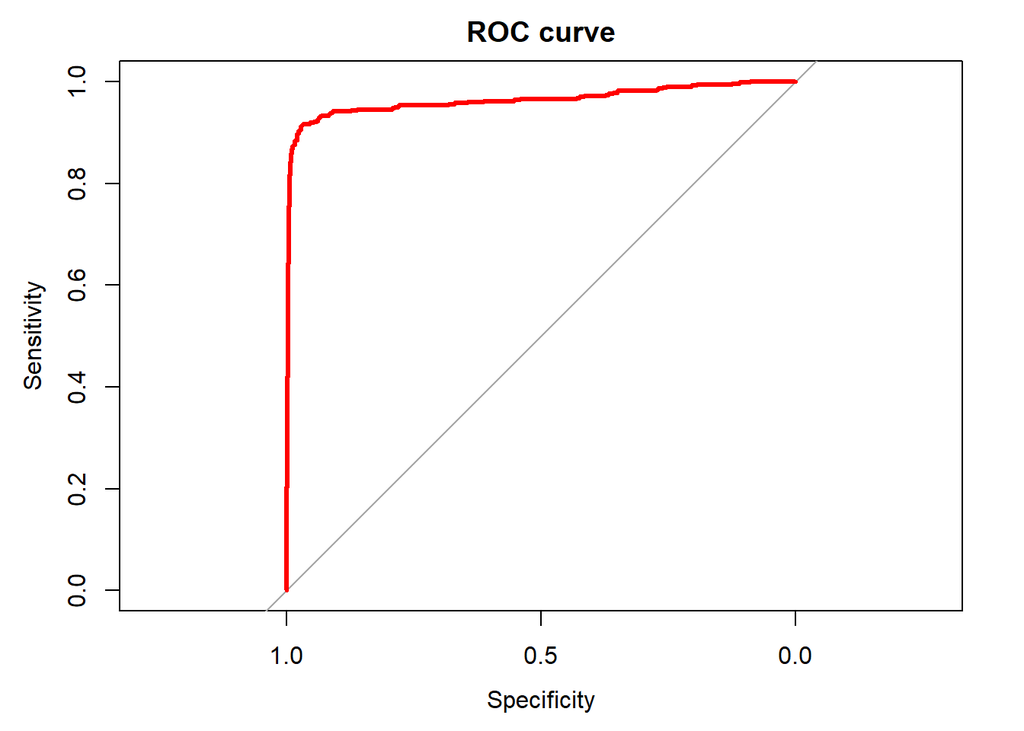

```
## [[1]]
##
## Call:
## roc.default(response = true_val, predictor = probs)
##
## Data: probs in 4877 controls (true_val X0) < 491 cases (true_val X1).
## Area under the curve: 0.9629
##
## [[2]]
## Area under the curve: 0.9629
```

```r
ROC_AUC <- function(true_val, probs){
  roc_curve=roc(response=true_val, predictor= probs)
  fig <- plot(roc_curve, col="red", lwd=3, main="ROC curve")
  score <- auc(roc_curve)
  ro_au <- list(fig, score)
  return(ro_au)
}
svm_probs <- predict(svm_nl_tuned, newdata = validate_df, type = 'prob')
ROC_AUC(as.factor(make.names(validate_df$Pulsar)), svm_probs$X1)
```

### **b] Artificial Neural Networks**

##### **Transforming the data for neural networks:**

##### All the data should be numeric data type except the target variable. Trying the **‘receipe’** library for preprocessing the data. Since, our data is already pre-processed and cleaned we do not need to do much.

##### Splitting the data into training and validation to check for the overfitting of the deep learning models.

```r
set.seed(73)
rec_obj <- recipe(Pulsar ~ ., data = train_sm) %>% prep(data = train_sm)

train_x <- bake(rec_obj, new_data = train_sm)
validate_x <- bake(rec_obj, new_data = validate_df)
train_y <- ifelse(pull(train_sm, Pulsar) == "1", 1, 0)
validate_y <- ifelse(pull(validate_df, Pulsar) == "1", 1, 0)

train_x <- train_x[, -which(colnames(train_x) == "Pulsar")]
validate_x <- validate_x[, -which(colnames(validate_x) == "Pulsar")]
```

##### **Model Description:**

##### Aritificial neural network with 2 hidden layers is a multilayer perceptron model. There will be an input layer, 2 hidden layers and a output layer. Input layer is nothing but the training example, so we do not need to specify it. The **linear combination** of input values and weights of the links is processed through and converted to required format by activation function. In this case the activation function for the output layer is **sigmoid function**, since this is a binary classification problem.

##### **Strategy:** Since, grid search is not possible in keras, we will be using nested for loops for tuning the hyperparamters.

##### **Hyperparameters:**

##### 1] epochs: Number of epochs is the numer of times that whole dataset has completed a forward and backward journey through the network.

##### 2] batch size: It is not possible to send whole data at once through the network, hence we create small batches of training examples. Number of example in any batch is known as batch size.

##### 3] Nodes in Hidden Layer 2: In addition to batch size and epochs, we will tunenumber of nodes in second hidden layer.

##### **Nodes and Layers:**

##### In the input layer we will have nodes = number of variables and in the output node there will be only one node since, it is a binary classification problem. For a multiple class classification, nodes in output function = number of classes.

##### **Activation Function:**

##### For output layer, it will be **Sigmoid Function**, because this is a binary classification problem and output of sigmoid function is probability between 0 and 1. We will use the threshold of 0.5 to classify as either 1 or 0. For both the hidden layers we will be using **‘Relu’** acivation function.

##### **Regularization:**

##### layer_dropout: Temporarily some random nodes are dropped out from a particular layer i.e. they are not considered in calculation for forward pass nor are they considered for updating weights in backward pass. This helps other nodes in that layer to develp relation within network. Here, we specify the probability of dropout to be 20% for 1st hidden layer and 10% for 2nd hidden layer.

##### **Optimzation:**

```r
batch_size_grid <- c(64,128)
epochs_grid <- c(40,60)
hid_nod_grid <- c(5,7,9)

ann2_models <- list()
ann2_fits <- list()

p <- 1
for (i in 1:length(batch_size_grid)){
  for (j in 1:length(epochs_grid)){
   for (k in 1:length(hid_nod_grid)){
      keras2_model <- keras_model_sequential()
      keras2_model %>%
        layer_dense(units = 9, kernel_initializer = "uniform", activation = "relu", input_shape
                    = ncol(train_x)) %>%
        layer_dropout(rate = 0.2) %>%
        layer_dense(units = hid_nod_grid[k], kernel_initializer = "uniform", activation =
                      "relu") %>%
        layer_dropout(rate = 0.1) %>%
        layer_dense(units = 1, kernel_initializer = "uniform", activation = "sigmoid") %>%
        compile(optimizer = "adam", loss = "binary_crossentropy", metrics = c("accuracy"))

      keras2_fit <- fit(object = keras2_model, x = as.matrix(train_x), y = train_y, batch_size =
                          batch_size_grid[i], epochs = epochs_grid[j], validation_split = 0.20,
                          verbose = F)
      ann2_models[[p]] <- keras2_model
      ann2_fits[[p]] <- keras2_fit
      p <- p + 1
    }
  }
}
```

##### **Finding the Best Model:**

##### Using the **average validation accuracy** over all epochs as metric to select best model.

```r
avg_acc <- c()
for (i in 1:length(ann2_models)){
  valacc <- ann2_fits[[i]]$metrics$val_accuracy
  avg_acc[i] <- sum(valacc)/length(valacc)
}
best_model_Index <- which.max(avg_acc)
keras2_best_model <- ann2_models[best_model_Index][[1]]
keras2_best_fit <- ann2_fits[best_model_Index][[1]]

paste0("Batch Size for best model is: ", keras2_best_fit$params$batch_size)
```

```
## [1] "Batch Size for best model is: 64"
```

```r
paste0("No. Epochs for best model is: ", keras2_best_fit$params$epochs)
```

```
## [1] "No. Epochs for best model is: 60"
```

##### Plotting the fitted model over the training dataset. This plots gives us the comparison between training accuracy/loss and validation accuracy/loss. If the difference between training and validation accuracy is increasing that means the model is getting overfitted.

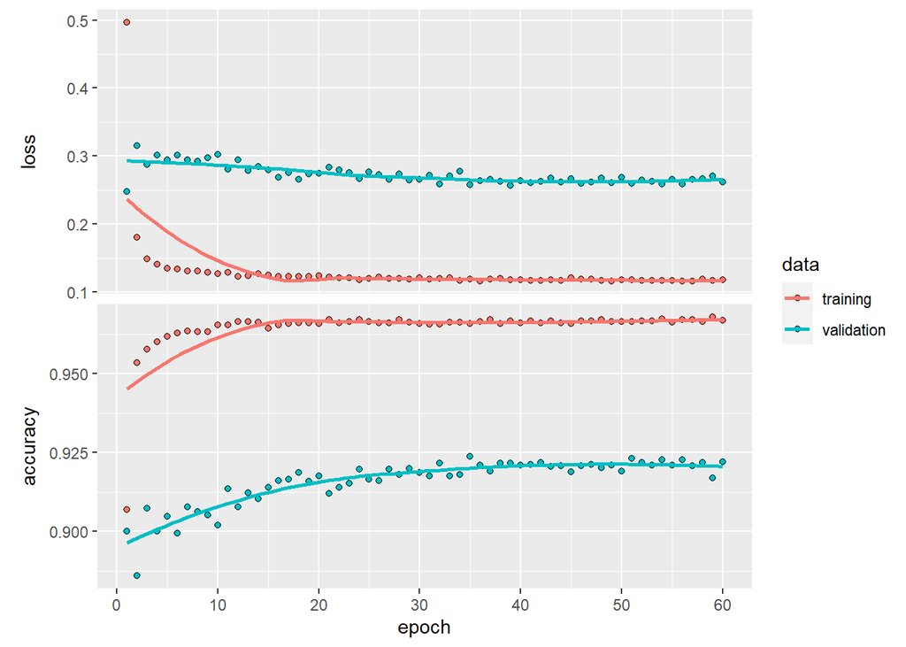

```r
plot(keras2_best_fit)
```

##### **Predictions:**

##### Now, making prediction on the validation data using the best model. Predicting the classes as well as the probabilities for the instances.

```r
pred_class_keras2 <- predict_classes(object = keras2_best_model, x = as.matrix(validate_x)) %>%
as.vector()
pred_prob_keras2 <- predict_proba(object = keras2_best_model, x = as.matrix(validate_x)) %>%
as.vector()
```

##### **Performance Evaluation Parameters:**

##### Plotting the confusion matrix and calculating **Accuracy, Recall and Precision**.

```r
estimates_keras2_tbl <- tibble(truth = as.factor(validate_y),estimate =
                                 as.factor(pred_class_keras2),class_prob = pred_prob_keras2)

options(yardstick.event_first = F)
estimates_keras2_tbl %>% conf_mat(truth, estimate)
```

```
##           Truth
## Prediction    0    1
##          0 4809   62
##          1   68  429
```

```r
estimates_keras2_tbl %>% metrics(truth, estimate)
```

```
## # A tibble: 2 x 3
##   .metric  .estimator .estimate
##   <chr>    <chr>          <dbl>
## 1 accuracy binary         0.976
## 2 kap      binary         0.855
```

```r
estimates_keras2_tbl %>% recall(truth, estimate)
```

```
## # A tibble: 1 x 3
##   .metric .estimator .estimate
##   <chr>   <chr>          <dbl>
## 1 recall  binary         0.874
```

```r
estimates_keras2_tbl %>% precision(truth, estimate, beta = 1)
```

```
## # A tibble: 1 x 3
##   .metric   .estimator .estimate
##   <chr>     <chr>          <dbl>
## 1 precision binary         0.863
```

##### **ROC and AUC:**

##### Plotting the ROC curve and calculating the area under curve.

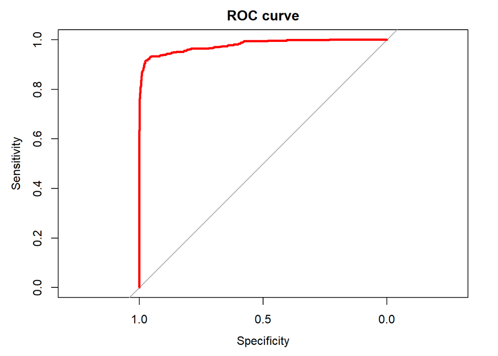

```
## [[1]]
##
## Call:
## roc.default(response = true_val, predictor = probs)
##
## Data: probs in 4877 controls (true_val 0) < 491 cases (true_val 1).
## Area under the curve: 0.9779
##
## [[2]]
## Area under the curve: 0.9779
```

```r
ROC_AUC(validate_y, pred_prob_keras2)
```

### **Code used for testing, but not a part of the assignment**

##### **Gradient Boosting Machine**

##### **Gradient Boosting Machine - Base Model**

##### **Model Description:** Just like random forest GBM model also works with multiple decision trees. Only diffrence is that in random forest all the trees run in parallel. **In GBM, trees run in series**. After every iterations the **weights** for the samples (observations) are updated. The samples which were misclassified are given more weights than the one which were classified correctly. Adding to that **boosting works on sampling with replacement**. The samples which were not selected in the first iterations will also be given **higher weights** in next iterations. In this way the model progresses and helps us in **reducing the bias**.

```r
#gbm_base <- train(Pulsar ~ ., data = train_sm, method = "gbm", verbose = F)
#print(gbm_base)
```

##### **Predictions:** Now, predicting the values on validation data using the baseline gradient boosting model.

```r
#gbm_base_predict <- predict(gbm_base, newdata = validate_df)
#confusionMatrix(gbm_base_predict, validate_df$Pulsar, positive = "1", mode = "prec_recall")
```

### **GBM Tuned**

##### Now tuning the hyperparameters, we will be tuning model as a whole and individual trees as well:

##### 1]**interaction.depth**: this parameter specifies that how many splits we will perform on every decision tree in so that we will get the specified number of nodes in a decision tree. It is the maximum number of nodes in a decision tree. The value “6” is generally considered to be best for giving significant results.

##### 2] **n.tree**: This value tells the model how many decision trees to include in our entire model.

##### 3] **shrinkage**: This parameter defines the learning rate of gbm model. Just like L1 regularisations helps in reducing the unimportant features in regression, shrinkage parameter in gbm helps reduce the importance of useless decision trees. Smaller teh value for shrinkage parameter, slower the model will converge to the global minima. “0.01” values is preferred for any datasets having 10,000+ observations.

##### 4] **n.minobsinnode**: minimum number of observations in the leaf nodes of the decision trees. 10 is considered to be good and big enough number. It should be less for smaller data with respect to rows.

```r
#tuneGrid_gbm <- expand.grid(interaction.depth=c(6,10,14), n.trees = c(800,1000,1200),
#                            shrinkage=c(0.01), n.minobsinnode=c(10,15,20))

#trainControl_gbm <- trainControl(method="cv", number=3, classProbs = TRUE, summaryFunction =
#                                   prSummary)
#set.seed(73)
#gbm_tuned <- train(make.names(Pulsar) ~ ., data = train_sm,
#                       tuneGrid = expand.grid(tuneGrid_gbm), method = "gbm",
#                       trControl = trainControl_gbm, verbose=F, metric="Recall")
#print(gbm_tuned)
```

##### **Predictions:** Now, predicting the values on validation data using the tuned gradient boosting model.

```r
#gbm_tuned_predict <- predict(gbm_tuned, newdata = validate_df)
#confusionMatrix(gbm_tuned_predict, as.factor(make.names(validate_df$Pulsar)), positive = "X1", mode = "prec_recall")
```